# Risk Factor Analysis

## Outcome Variable

**Outcome Variable:** ever_wasted

## Predictor Variables

**Intervention Variable:** parity

**Adjustment Set:**

unadjusted

## Stratifying Variables

The analysis was stratified on these variable(s):

- agecat
- studyid
- country

## Data Summary

| agecat | studyid | country | parity | ever_wasted | n_cell | n |
| --- | --- | --- | --- | --- | --- | --- |
| 0-24 months | COHORTS | GUATEMALA | 1 | 0 | 162 | 1341 |
| 0-24 months | COHORTS | GUATEMALA | 1 | 1 | 46 | 1341 |
| 0-24 months | COHORTS | GUATEMALA | 2 | 0 | 132 | 1341 |
| 0-24 months | COHORTS | GUATEMALA | 2 | 1 | 55 | 1341 |
| 0-24 months | COHORTS | GUATEMALA | 3+ | 0 | 705 | 1341 |
| 0-24 months | COHORTS | GUATEMALA | 3+ | 1 | 241 | 1341 |
| 0-24 months | COHORTS | INDIA | 1 | 0 | 560 | 4624 |
| 0-24 months | COHORTS | INDIA | 1 | 1 | 250 | 4624 |
| 0-24 months | COHORTS | INDIA | 2 | 0 | 821 | 4624 |
| 0-24 months | COHORTS | INDIA | 2 | 1 | 363 | 4624 |
| 0-24 months | COHORTS | INDIA | 3+ | 0 | 1681 | 4624 |
| 0-24 months | COHORTS | INDIA | 3+ | 1 | 949 | 4624 |
| 0-24 months | COHORTS | PHILIPPINES | 1 | 0 | 394 | 3045 |
| 0-24 months | COHORTS | PHILIPPINES | 1 | 1 | 283 | 3045 |
| 0-24 months | COHORTS | PHILIPPINES | 2 | 0 | 424 | 3045 |
| 0-24 months | COHORTS | PHILIPPINES | 2 | 1 | 258 | 3045 |
| 0-24 months | COHORTS | PHILIPPINES | 3+ | 0 | 998 | 3045 |
| 0-24 months | COHORTS | PHILIPPINES | 3+ | 1 | 688 | 3045 |
| 0-24 months | GMS-Nepal | NEPAL | 1 | 0 | 89 | 686 |
| 0-24 months | GMS-Nepal | NEPAL | 1 | 1 | 114 | 686 |
| 0-24 months | GMS-Nepal | NEPAL | 2 | 0 | 78 | 686 |
| 0-24 months | GMS-Nepal | NEPAL | 2 | 1 | 102 | 686 |
| 0-24 months | GMS-Nepal | NEPAL | 3+ | 0 | 114 | 686 |
| 0-24 months | GMS-Nepal | NEPAL | 3+ | 1 | 189 | 686 |
| 0-24 months | Keneba | GAMBIA | 1 | 0 | 131 | 1990 |
| 0-24 months | Keneba | GAMBIA | 1 | 1 | 109 | 1990 |
| 0-24 months | Keneba | GAMBIA | 2 | 0 | 118 | 1990 |
| 0-24 months | Keneba | GAMBIA | 2 | 1 | 96 | 1990 |
| 0-24 months | Keneba | GAMBIA | 3+ | 0 | 771 | 1990 |
| 0-24 months | Keneba | GAMBIA | 3+ | 1 | 765 | 1990 |

[output cut: 150 more lines]

The following strata were considered:

- agecat: 0-24 months, studyid: COHORTS, country: GUATEMALA
- agecat: 0-24 months, studyid: COHORTS, country: INDIA
- agecat: 0-24 months, studyid: COHORTS, country: PHILIPPINES
- agecat: 0-24 months, studyid: GMS-Nepal, country: NEPAL
- agecat: 0-24 months, studyid: Keneba, country: GAMBIA
- agecat: 0-24 months, studyid: PROVIDE, country: BANGLADESH
- agecat: 0-24 months, studyid: SAS-CompFeed, country: INDIA
- agecat: 0-24 months, studyid: SAS-FoodSuppl, country: INDIA
- agecat: 0-24 months, studyid: TanzaniaChild2, country: TANZANIA, UNITED REPUBLIC OF
- agecat: 0-24 months, studyid: ZVITAMBO, country: ZIMBABWE
- agecat: 0-6 months, studyid: COHORTS, country: GUATEMALA
- agecat: 0-6 months, studyid: COHORTS, country: INDIA
- agecat: 0-6 months, studyid: COHORTS, country: PHILIPPINES
- agecat: 0-6 months, studyid: GMS-Nepal, country: NEPAL
- agecat: 0-6 months, studyid: Keneba, country: GAMBIA
- agecat: 0-6 months, studyid: PROVIDE, country: BANGLADESH
- agecat: 0-6 months, studyid: SAS-CompFeed, country: INDIA
- agecat: 0-6 months, studyid: SAS-FoodSuppl, country: INDIA
- agecat: 0-6 months, studyid: TanzaniaChild2, country: TANZANIA, UNITED REPUBLIC OF
- agecat: 0-6 months, studyid: ZVITAMBO, country: ZIMBABWE
- agecat: 6-24 months, studyid: COHORTS, country: GUATEMALA
- agecat: 6-24 months, studyid: COHORTS, country: INDIA
- agecat: 6-24 months, studyid: COHORTS, country: PHILIPPINES
- agecat: 6-24 months, studyid: GMS-Nepal, country: NEPAL
- agecat: 6-24 months, studyid: Keneba, country: GAMBIA
- agecat: 6-24 months, studyid: PROVIDE, country: BANGLADESH
- agecat: 6-24 months, studyid: SAS-CompFeed, country: INDIA
- agecat: 6-24 months, studyid: SAS-FoodSuppl, country: INDIA
- agecat: 6-24 months, studyid: TanzaniaChild2, country: TANZANIA, UNITED REPUBLIC OF
- agecat: 6-24 months, studyid: ZVITAMBO, country: ZIMBABWE

### Dropped Strata

Some strata were dropped due to rare outcomes:

- agecat: 6-24 months, studyid: SAS-FoodSuppl, country: INDIA

## Methods Detail

We’re interested in the causal parameters $E[Y_a]$ for all values of $a \in \mathcal{A}$. These parameters represent the mean outcome if, possibly contrary to fact, we intervened to set all units to have $A=a$. Under the randomization and positivity assumptions, these are identified by the statistical parameters $\psi_a=E_W[E_{Y|A,W}(Y|A=a,W)]$. In addition, we’re interested in the mean of $Y$, $E[Y]$ under no intervention (the observed mean). We will estimate these parameters by using SuperLearner to fit the relevant likelihood factors – $E_{Y|A,W}(Y|A=a,W)$ and $p(A=a|W)$, and then updating our likelihood fit using a joint TMLE.

For unadjusted analyses ($W=\{\}$), initial likelihoods were estimated using Lrnr_glm to estimate the simple $E(Y|A)$ and Lrnr_mean to estimate $p(A)$. For adjusted analyses, a small library containing Lrnr_glmnet, Lrnr_xgboost, and Lrnr_mean was used.

Having estimated these parameters, we will then use the delta method to estimate relative risks and attributable risks relative to a prespecified baseline level of $A$.

# Results Detail

## Results Plots

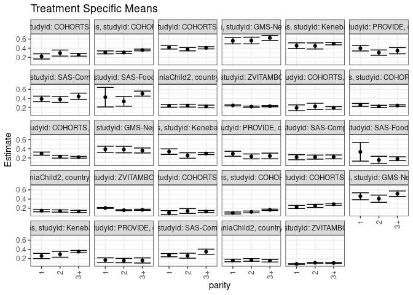

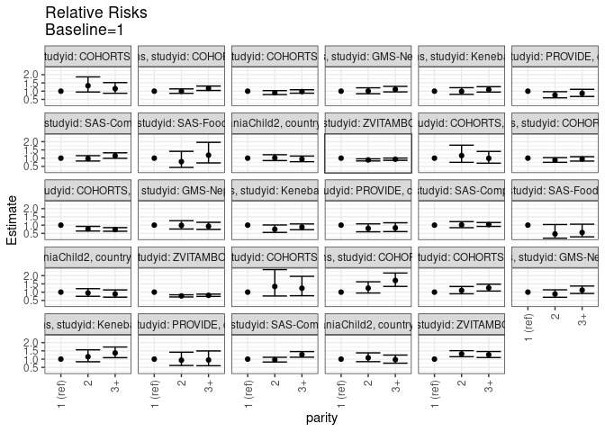

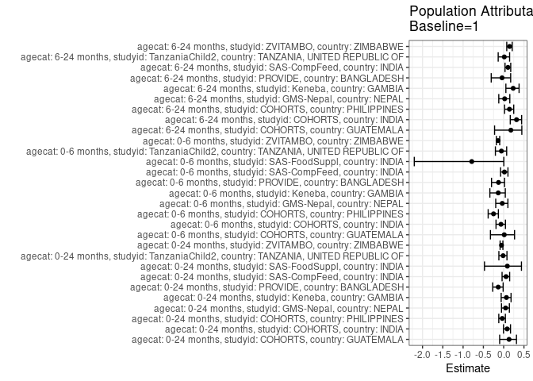

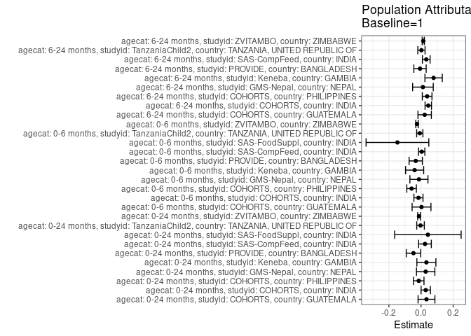

## Results Table

### Parameter: TSM

| agecat | studyid | country | intervention_level | baseline_level | estimate | ci_lower | ci_upper |
| --- | --- | --- | --- | --- | --- | --- | --- |
| 0-24 months | COHORTS | GUATEMALA | 1 | NA | 0.2211538 | 0.1647315 | 0.2775762 |
| 0-24 months | COHORTS | GUATEMALA | 2 | NA | 0.2941176 | 0.2287871 | 0.3594481 |
| 0-24 months | COHORTS | GUATEMALA | 3+ | NA | 0.2547569 | 0.2269804 | 0.2825333 |
| 0-24 months | COHORTS | INDIA | 1 | NA | 0.3086420 | 0.2768270 | 0.3404569 |
| 0-24 months | COHORTS | INDIA | 2 | NA | 0.3065878 | 0.2803219 | 0.3328537 |
| 0-24 months | COHORTS | INDIA | 3+ | NA | 0.3608365 | 0.3424805 | 0.3791925 |
| 0-24 months | COHORTS | PHILIPPINES | 1 | NA | 0.4180207 | 0.3808605 | 0.4551809 |
| 0-24 months | COHORTS | PHILIPPINES | 2 | NA | 0.3782991 | 0.3418962 | 0.4147020 |
| 0-24 months | COHORTS | PHILIPPINES | 3+ | NA | 0.4080664 | 0.3846029 | 0.4315299 |
| 0-24 months | GMS-Nepal | NEPAL | 1 | NA | 0.5615764 | 0.4932689 | 0.6298838 |
| 0-24 months | GMS-Nepal | NEPAL | 2 | NA | 0.5666667 | 0.4942225 | 0.6391108 |
| 0-24 months | GMS-Nepal | NEPAL | 3+ | NA | 0.6237624 | 0.5691760 | 0.6783488 |
| 0-24 months | Keneba | GAMBIA | 1 | NA | 0.4541667 | 0.3911596 | 0.5171737 |
| 0-24 months | Keneba | GAMBIA | 2 | NA | 0.4485981 | 0.3819461 | 0.5152501 |
| 0-24 months | Keneba | GAMBIA | 3+ | NA | 0.4980469 | 0.4730360 | 0.5230577 |
| 0-24 months | PROVIDE | BANGLADESH | 1 | NA | 0.3985240 | 0.3401915 | 0.4568564 |
| 0-24 months | PROVIDE | BANGLADESH | 2 | NA | 0.3032787 | 0.2455603 | 0.3609971 |
| 0-24 months | PROVIDE | BANGLADESH | 3+ | NA | 0.3459459 | 0.2773523 | 0.4145395 |
| 0-24 months | SAS-CompFeed | INDIA | 1 | NA | 0.3906250 | 0.3307995 | 0.4504505 |
| 0-24 months | SAS-CompFeed | INDIA | 2 | NA | 0.3813559 | 0.3153859 | 0.4473260 |
| 0-24 months | SAS-CompFeed | INDIA | 3+ | NA | 0.4472574 | 0.3772779 | 0.5172369 |
| 0-24 months | SAS-FoodSuppl | INDIA | 1 | NA | 0.4285714 | 0.2166616 | 0.6404813 |
| 0-24 months | SAS-FoodSuppl | INDIA | 2 | NA | 0.3376623 | 0.2319066 | 0.4434181 |
| 0-24 months | SAS-FoodSuppl | INDIA | 3+ | NA | 0.5062500 | 0.4514060 | 0.5610940 |
| 0-24 months | TanzaniaChild2 | TANZANIA, UNITED REPUBLIC OF | 1 | NA | 0.2399513 | 0.2107333 | 0.2691693 |
| 0-24 months | TanzaniaChild2 | TANZANIA, UNITED REPUBLIC OF | 2 | NA | 0.2438392 | 0.2135232 | 0.2741552 |
| 0-24 months | TanzaniaChild2 | TANZANIA, UNITED REPUBLIC OF | 3+ | NA | 0.2261438 | 0.1964933 | 0.2557943 |
| 0-24 months | ZVITAMBO | ZIMBABWE | 1 | NA | 0.2492507 | 0.2383103 | 0.2601912 |
| 0-24 months | ZVITAMBO | ZIMBABWE | 2 | NA | 0.2221158 | 0.2095113 | 0.2347204 |
| 0-24 months | ZVITAMBO | ZIMBABWE | 3+ | NA | 0.2329168 | 0.2194075 | 0.2464261 |

[output cut: 57 more lines]

### Parameter: E(Y)

| agecat | studyid | country | intervention_level | baseline_level | estimate | ci_lower | ci_upper |
| --- | --- | --- | --- | --- | --- | --- | --- |
| 0-24 months | COHORTS | GUATEMALA | NA | NA | 0.2550336 | 0.2316956 | 0.2783715 |
| 0-24 months | COHORTS | INDIA | NA | NA | 0.3378028 | 0.3241691 | 0.3514364 |
| 0-24 months | COHORTS | PHILIPPINES | NA | NA | 0.4036125 | 0.3861835 | 0.4210415 |
| 0-24 months | GMS-Nepal | NEPAL | NA | NA | 0.5903790 | 0.5535526 | 0.6272054 |
| 0-24 months | Keneba | GAMBIA | NA | NA | 0.4874372 | 0.4654705 | 0.5094038 |
| 0-24 months | PROVIDE | BANGLADESH | NA | NA | 0.3514286 | 0.3160364 | 0.3868207 |
| 0-24 months | SAS-CompFeed | INDIA | NA | NA | 0.4150694 | 0.3581204 | 0.4720184 |
| 0-24 months | SAS-FoodSuppl | INDIA | NA | NA | 0.4712919 | 0.4233811 | 0.5192026 |
| 0-24 months | TanzaniaChild2 | TANZANIA, UNITED REPUBLIC OF | NA | NA | 0.2367416 | 0.2195770 | 0.2539062 |
| 0-24 months | ZVITAMBO | ZIMBABWE | NA | NA | 0.2367157 | 0.2296604 | 0.2437709 |
| 0-6 months | COHORTS | GUATEMALA | NA | NA | 0.2003763 | 0.1763021 | 0.2244505 |
| 0-6 months | COHORTS | INDIA | NA | NA | 0.2434743 | 0.2308547 | 0.2560940 |
| 0-6 months | COHORTS | PHILIPPINES | NA | NA | 0.2355453 | 0.2204685 | 0.2506222 |
| 0-6 months | GMS-Nepal | NEPAL | NA | NA | 0.3760933 | 0.3398180 | 0.4123685 |
| 0-6 months | Keneba | GAMBIA | NA | NA | 0.2976769 | 0.2768415 | 0.3185124 |
| 0-6 months | PROVIDE | BANGLADESH | NA | NA | 0.2585714 | 0.2261125 | 0.2910304 |
| 0-6 months | SAS-CompFeed | INDIA | NA | NA | 0.2199336 | 0.1753445 | 0.2645227 |
| 0-6 months | SAS-FoodSuppl | INDIA | NA | NA | 0.1866029 | 0.1492099 | 0.2239959 |
| 0-6 months | TanzaniaChild2 | TANZANIA, UNITED REPUBLIC OF | NA | NA | 0.1395842 | 0.1255905 | 0.1535779 |
| 0-6 months | ZVITAMBO | ZIMBABWE | NA | NA | 0.1811291 | 0.1747154 | 0.1875428 |
| 6-24 months | COHORTS | GUATEMALA | NA | NA | 0.1269580 | 0.1082147 | 0.1457012 |
| 6-24 months | COHORTS | INDIA | NA | NA | 0.1419682 | 0.1315821 | 0.1523542 |
| 6-24 months | COHORTS | PHILIPPINES | NA | NA | 0.2666429 | 0.2502871 | 0.2829988 |
| 6-24 months | GMS-Nepal | NEPAL | NA | NA | 0.4728814 | 0.4325613 | 0.5132014 |
| 6-24 months | Keneba | GAMBIA | NA | NA | 0.3336798 | 0.3126050 | 0.3547547 |
| 6-24 months | PROVIDE | BANGLADESH | NA | NA | 0.1609756 | 0.1319065 | 0.1900447 |
| 6-24 months | SAS-CompFeed | INDIA | NA | NA | 0.3059755 | 0.2638053 | 0.3481458 |
| 6-24 months | TanzaniaChild2 | TANZANIA, UNITED REPUBLIC OF | NA | NA | 0.1600403 | 0.1439152 | 0.1761654 |
| 6-24 months | ZVITAMBO | ZIMBABWE | NA | NA | 0.0958942 | 0.0903444 | 0.1014441 |

### Parameter: RR

| agecat | studyid | country | intervention_level | baseline_level | estimate | ci_lower | ci_upper |
| --- | --- | --- | --- | --- | --- | --- | --- |
| 0-24 months | COHORTS | GUATEMALA | 1 | 1 | 1.0000000 | 1.0000000 | 1.0000000 |
| 0-24 months | COHORTS | GUATEMALA | 2 | 1 | 1.3299233 | 0.9482357 | 1.8652492 |
| 0-24 months | COHORTS | GUATEMALA | 3+ | 1 | 1.1519441 | 0.8728447 | 1.5202878 |
| 0-24 months | COHORTS | INDIA | 1 | 1 | 1.0000000 | 1.0000000 | 1.0000000 |
| 0-24 months | COHORTS | INDIA | 2 | 1 | 0.9933446 | 0.8687394 | 1.1358222 |
| 0-24 months | COHORTS | INDIA | 3+ | 1 | 1.1691103 | 1.0421578 | 1.3115277 |
| 0-24 months | COHORTS | PHILIPPINES | 1 | 1 | 1.0000000 | 1.0000000 | 1.0000000 |
| 0-24 months | COHORTS | PHILIPPINES | 2 | 1 | 0.9049770 | 0.7938583 | 1.0316494 |
| 0-24 months | COHORTS | PHILIPPINES | 3+ | 1 | 0.9761872 | 0.8781205 | 1.0852058 |
| 0-24 months | GMS-Nepal | NEPAL | 1 | 1 | 1.0000000 | 1.0000000 | 1.0000000 |
| 0-24 months | GMS-Nepal | NEPAL | 2 | 1 | 1.0090643 | 0.8458285 | 1.2038029 |
| 0-24 months | GMS-Nepal | NEPAL | 3+ | 1 | 1.1107348 | 0.9561669 | 1.2902891 |
| 0-24 months | Keneba | GAMBIA | 1 | 1 | 1.0000000 | 1.0000000 | 1.0000000 |
| 0-24 months | Keneba | GAMBIA | 2 | 1 | 0.9877390 | 0.8060459 | 1.2103881 |
| 0-24 months | Keneba | GAMBIA | 3+ | 1 | 1.0966170 | 0.9461914 | 1.2709572 |
| 0-24 months | PROVIDE | BANGLADESH | 1 | 1 | 1.0000000 | 1.0000000 | 1.0000000 |
| 0-24 months | PROVIDE | BANGLADESH | 2 | 1 | 0.7610049 | 0.5985725 | 0.9675159 |
| 0-24 months | PROVIDE | BANGLADESH | 3+ | 1 | 0.8680681 | 0.6784546 | 1.1106744 |
| 0-24 months | SAS-CompFeed | INDIA | 1 | 1 | 1.0000000 | 1.0000000 | 1.0000000 |
| 0-24 months | SAS-CompFeed | INDIA | 2 | 1 | 0.9762712 | 0.8276984 | 1.1515129 |
| 0-24 months | SAS-CompFeed | INDIA | 3+ | 1 | 1.1449789 | 0.9904415 | 1.3236285 |
| 0-24 months | SAS-FoodSuppl | INDIA | 1 | 1 | 1.0000000 | 1.0000000 | 1.0000000 |
| 0-24 months | SAS-FoodSuppl | INDIA | 2 | 1 | 0.7878788 | 0.4387984 | 1.4146657 |
| 0-24 months | SAS-FoodSuppl | INDIA | 3+ | 1 | 1.1812500 | 0.7120467 | 1.9596350 |
| 0-24 months | TanzaniaChild2 | TANZANIA, UNITED REPUBLIC OF | 1 | 1 | 1.0000000 | 1.0000000 | 1.0000000 |
| 0-24 months | TanzaniaChild2 | TANZANIA, UNITED REPUBLIC OF | 2 | 1 | 1.0162028 | 0.8538912 | 1.2093674 |
| 0-24 months | TanzaniaChild2 | TANZANIA, UNITED REPUBLIC OF | 3+ | 1 | 0.9424571 | 0.7880450 | 1.1271253 |
| 0-24 months | ZVITAMBO | ZIMBABWE | 1 | 1 | 1.0000000 | 1.0000000 | 1.0000000 |
| 0-24 months | ZVITAMBO | ZIMBABWE | 2 | 1 | 0.8911341 | 0.8294417 | 0.9574151 |
| 0-24 months | ZVITAMBO | ZIMBABWE | 3+ | 1 | 0.9344677 | 0.8689102 | 1.0049714 |

[output cut: 57 more lines]

### Parameter: PAR

| agecat | studyid | country | intervention_level | baseline_level | estimate | ci_lower | ci_upper |
| --- | --- | --- | --- | --- | --- | --- | --- |
| 0-24 months | COHORTS | GUATEMALA | 1 | NA | 0.0338797 | -0.0184708 | 0.0862302 |
| 0-24 months | COHORTS | INDIA | 1 | NA | 0.0291608 | 0.0001186 | 0.0582030 |
| 0-24 months | COHORTS | PHILIPPINES | 1 | NA | -0.0144082 | -0.0471286 | 0.0183122 |
| 0-24 months | GMS-Nepal | NEPAL | 1 | NA | 0.0288027 | -0.0282993 | 0.0859046 |
| 0-24 months | Keneba | GAMBIA | 1 | NA | 0.0332705 | -0.0258468 | 0.0923879 |
| 0-24 months | PROVIDE | BANGLADESH | 1 | NA | -0.0470954 | -0.0920469 | -0.0021439 |
| 0-24 months | SAS-CompFeed | INDIA | 1 | NA | 0.0244444 | -0.0150202 | 0.0639090 |
| 0-24 months | SAS-FoodSuppl | INDIA | 1 | NA | 0.0427204 | -0.1638931 | 0.2493340 |
| 0-24 months | TanzaniaChild2 | TANZANIA, UNITED REPUBLIC OF | 1 | NA | -0.0032097 | -0.0267382 | 0.0203189 |
| 0-24 months | ZVITAMBO | ZIMBABWE | 1 | NA | -0.0125351 | -0.0206817 | -0.0043884 |
| 0-6 months | COHORTS | GUATEMALA | 1 | NA | 0.0030079 | -0.0556511 | 0.0616668 |
| 0-6 months | COHORTS | INDIA | 1 | NA | -0.0160777 | -0.0443590 | 0.0122036 |
| 0-6 months | COHORTS | PHILIPPINES | 1 | NA | -0.0588334 | -0.0885596 | -0.0291072 |
| 0-6 months | GMS-Nepal | NEPAL | 1 | NA | -0.0130693 | -0.0692355 | 0.0430970 |
| 0-6 months | Keneba | GAMBIA | 1 | NA | -0.0399299 | -0.0963088 | 0.0164490 |
| 0-6 months | PROVIDE | BANGLADESH | 1 | NA | -0.0329415 | -0.0743581 | 0.0084751 |
| 0-6 months | SAS-CompFeed | INDIA | 1 | NA | 0.0042032 | -0.0153692 | 0.0237756 |
| 0-6 months | SAS-FoodSuppl | INDIA | 1 | NA | -0.1467305 | -0.3417992 | 0.0483382 |
| 0-6 months | TanzaniaChild2 | TANZANIA, UNITED REPUBLIC OF | 1 | NA | -0.0077970 | -0.0271428 | 0.0115488 |
| 0-6 months | ZVITAMBO | ZIMBABWE | 1 | NA | -0.0250444 | -0.0325165 | -0.0175723 |
| 6-24 months | COHORTS | GUATEMALA | 1 | NA | 0.0225624 | -0.0190753 | 0.0642000 |
| 6-24 months | COHORTS | INDIA | 1 | NA | 0.0450226 | 0.0250340 | 0.0650113 |
| 6-24 months | COHORTS | PHILIPPINES | 1 | NA | 0.0380245 | 0.0080308 | 0.0680182 |
| 6-24 months | GMS-Nepal | NEPAL | 1 | NA | 0.0118035 | -0.0523058 | 0.0759129 |
| 6-24 months | Keneba | GAMBIA | 1 | NA | 0.0781732 | 0.0242759 | 0.1320706 |
| 6-24 months | PROVIDE | BANGLADESH | 1 | NA | -0.0064253 | -0.0446808 | 0.0318303 |
| 6-24 months | SAS-CompFeed | INDIA | 1 | NA | 0.0325942 | 0.0089271 | 0.0562613 |
| 6-24 months | TanzaniaChild2 | TANZANIA, UNITED REPUBLIC OF | 1 | NA | 0.0025365 | -0.0199242 | 0.0249973 |
| 6-24 months | ZVITAMBO | ZIMBABWE | 1 | NA | 0.0140150 | 0.0075345 | 0.0204956 |

### Parameter: PAF

| agecat | studyid | country | intervention_level | baseline_level | estimate | ci_lower | ci_upper |
| --- | --- | --- | --- | --- | --- | --- | --- |
| 0-24 months | COHORTS | GUATEMALA | 1 | NA | 0.1328441 | -0.0985709 | 0.3155114 |
| 0-24 months | COHORTS | INDIA | 1 | NA | 0.0863249 | -0.0038186 | 0.1683735 |
| 0-24 months | COHORTS | PHILIPPINES | 1 | NA | -0.0356981 | -0.1200305 | 0.0422845 |
| 0-24 months | GMS-Nepal | NEPAL | 1 | NA | 0.0487867 | -0.0531148 | 0.1408281 |
| 0-24 months | Keneba | GAMBIA | 1 | NA | 0.0682560 | -0.0613077 | 0.1820026 |
| 0-24 months | PROVIDE | BANGLADESH | 1 | NA | -0.1340113 | -0.2695973 | -0.0129052 |
| 0-24 months | SAS-CompFeed | INDIA | 1 | NA | 0.0588923 | -0.0390883 | 0.1476339 |
| 0-24 months | SAS-FoodSuppl | INDIA | 1 | NA | 0.0906454 | -0.4727690 | 0.4385231 |
| 0-24 months | TanzaniaChild2 | TANZANIA, UNITED REPUBLIC OF | 1 | NA | -0.0135576 | -0.1179764 | 0.0811085 |
| 0-24 months | ZVITAMBO | ZIMBABWE | 1 | NA | -0.0529542 | -0.0879251 | -0.0191074 |
| 0-6 months | COHORTS | GUATEMALA | 1 | NA | 0.0150111 | -0.3258814 | 0.2682580 |
| 0-6 months | COHORTS | INDIA | 1 | NA | -0.0660345 | -0.1887387 | 0.0440040 |
| 0-6 months | COHORTS | PHILIPPINES | 1 | NA | -0.2497751 | -0.3823109 | -0.1299469 |
| 0-6 months | GMS-Nepal | NEPAL | 1 | NA | -0.0347501 | -0.1954168 | 0.1043227 |
| 0-6 months | Keneba | GAMBIA | 1 | NA | -0.1341384 | -0.3402566 | 0.0402809 |
| 0-6 months | PROVIDE | BANGLADESH | 1 | NA | -0.1273980 | -0.2993131 | 0.0217706 |
| 0-6 months | SAS-CompFeed | INDIA | 1 | NA | 0.0191113 | -0.0757596 | 0.1056156 |
| 0-6 months | SAS-FoodSuppl | INDIA | 1 | NA | -0.7863248 | -2.2032501 | 0.0038379 |
| 0-6 months | TanzaniaChild2 | TANZANIA, UNITED REPUBLIC OF | 1 | NA | -0.0558589 | -0.2038776 | 0.0739606 |
| 0-6 months | ZVITAMBO | ZIMBABWE | 1 | NA | -0.1382681 | -0.1801278 | -0.0978933 |
| 6-24 months | COHORTS | GUATEMALA | 1 | NA | 0.1777151 | -0.2240976 | 0.4476320 |
| 6-24 months | COHORTS | INDIA | 1 | NA | 0.3171319 | 0.1625951 | 0.4431501 |
| 6-24 months | COHORTS | PHILIPPINES | 1 | NA | 0.1426046 | 0.0225519 | 0.2479121 |
| 6-24 months | GMS-Nepal | NEPAL | 1 | NA | 0.0249608 | -0.1205028 | 0.1515404 |
| 6-24 months | Keneba | GAMBIA | 1 | NA | 0.2342761 | 0.0546472 | 0.3797733 |
| 6-24 months | PROVIDE | BANGLADESH | 1 | NA | -0.0399146 | -0.3068267 | 0.1724822 |
| 6-24 months | SAS-CompFeed | INDIA | 1 | NA | 0.1065256 | 0.0335461 | 0.1739942 |
| 6-24 months | TanzaniaChild2 | TANZANIA, UNITED REPUBLIC OF | 1 | NA | 0.0158494 | -0.1349883 | 0.1466411 |
| 6-24 months | ZVITAMBO | ZIMBABWE | 1 | NA | 0.1461508 | 0.0762949 | 0.2107238 |